# Mobile AI Functionality: Final Analysis

Final analysis

Published

December 8, 2024

# Abstract

This study focuses on a market analysis for a mobile AI software designed and intended for personal users. The analysis seeks to use survey data to generate a utility model for this software with the following attributes being studied: price, functionality, and question limit. The definition for price is the cost per month of the software, for functionality is how many different functions (texting, calendar, social media, ordering food, etc) the AI software is able to perform, and for question limit is the amount of requests that a user can make per day. The survey solicitation yielded around 200 initial responses; after processing and cleaning, the analysis had ~180 respondents. Through logit modelling, willingness to pay calculations, market competitor comparisons, and sensitivity analysis, our product is highly price sensitive in the market. Additionally, due to the prevalence of competitors that offer low cost and high functionality models, a robust product offering would be necessary to achieve a market share greater than 10-20%.

# Introduction

The product within this study is AI software technology on personal mobile phones. The purpose of this technology is to enhance a user’s experience with their personal device by enhancing its software intelligence and augmentation capabilities for tasks such as writing emails, generating ideas, managing notifications, performing tasks such as ride hailing, and much more. Figure 1 shows a high-level diagram of how the technology functions.

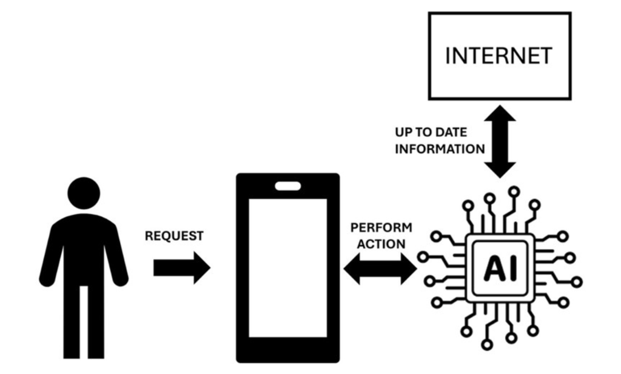

Figure 1: AI mobile software diagram

The attributes of AI software that are being investigated in this study are price, functionality, and question limit. These attributes were selected they are each things that other entries in the space advertise to consumers themselves. These other companies are 1) Apple Siri with Apple Intelligence, 2) ChatGPT, and 3) Google Gemini. At time of writing, Apple Intelligence is in beta and not yet available to customers [1]. These three competitors offer entries into the marketplace with Apple Intelligence being a free offering to current Apple device owners that is intended to enhance the integrated software-hardware experience, ChatGPT is a monthly subscription Large Language Model (LLM) that operates in a web browser or within applications, and Gemini from Google has multiple subscription levels ranging from free as part of their OS a paid subscription on other services that they offer such as Gmail.

# Survey Design

## Eligibility Requirements

The primary eligibility requirement for the survey was that respondents needed to be at least 18 years old, as reflected in the consent form. This requirement ensures that respondents are legally considered adults and capable of providing informed consent for participating in research. Additionally, participants were required to acknowledge their voluntary participation, which ensures ethical compliance in research studies. We also collected critical demographic information such as age, gender, income, race, and industry of employment, to understand the diversity of respondents and to control for these variables during analysis. These demographic questions help tailor insights to specific population segments and ensure the responses are relevant across various groups.

## Educational Material Presented

To ensure respondents were adequately informed before answering the conjoint questions, we provided a section called “Education Information.” This included a detailed explanation of the key attributes of the AI software, such as Price, Functionality, and Question Limit. These attributes were broken down into simple terms so that respondents could understand the differences between the options. This educational material ensured that the respondents had the necessary context to make informed choices in the conjoint questions.

## Attributes and Levels for Conjoint Choice Questions

The conjoint survey aimed to understand preferences for a hypothetical AI-enabled smartphone service. The three main attributes selected were:

The functionality of the AI is categorized into three levels: Low, Medium, and High.

- *Low* functionality: Complete a task within *one* source (e.g., edit grammar of an email draft)
- *Medium* functionality: Complete a task with up to *three* sources (e.g., check calendar to schedule a video call via email)
- *High* functionality: Complete a task with access to *all* relevant sources (i.e., cross-reference calendar, email, messages, and a flight booking website to help book the best flight)

**3. Question limit**: The number of questions or requests that you can ask the AI software *per day* (e.g., each input, such as “can you revise this email?” counts as a question). Levels at 50, 250, and 500 questions per day.

## **No-Choice Option**

A “no-choice” option was not explicitly included in this survey. All respondents were required to choose among the provided alternatives in each conjoint question. The absence of a no-choice option was deliberate to force participants to make a trade-off among the options, ensuring that their preferences were captured more clearly.

## Example Conjoint Question

An example conjoint question from the survey would look like this:

“If these were your only options, which AI-enabled smartphone software service would you choose?”

1. Price: $10
2. Functionality: Low
3. Question Limit: 50

The respondent would choose between several combinations of these attributes.

Find the below figure 2 for the screenshot of one of the conjoint questions from the survey.

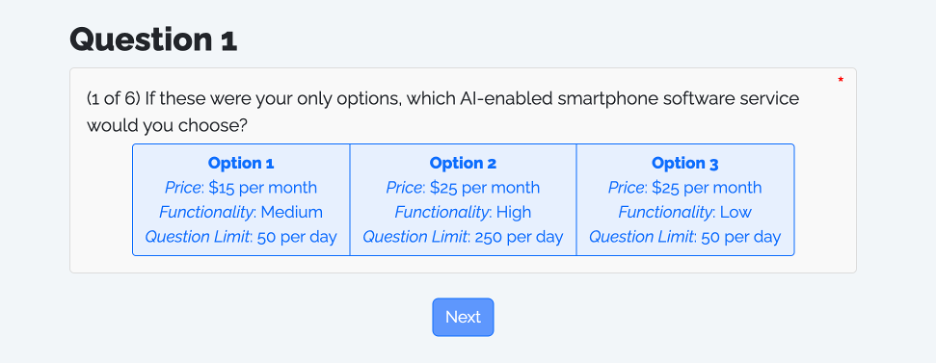

Figure 2: Conjoint question example

This design approach ensures that respondents are adequately prepared, the choice questions are relevant and balanced, and meaningful insights into preferences for AI-enabled smartphone services can be derived.

## Changes in Survey from Pilot

The only major change between the pilot survey and the final survey was to change the question limit value unlimited to 500. This was to allow the utility model to fit the question limit a continuous value rather that discrete.

# Data Analysis

## Sample description

The final survey involved a total of 221 respondents, with a potential of 1,326 conjoint question answers (6 questions per respondent). The target demographic of this study focused on smartphone users who rely on their devices for more than 50% of their daily tasks. Respondents for the final survey were sourced beyond the initial sample of classmates to ensure a broader representation within the defined target demographic.

## Raw data summary

Below shows a summary table of the survey response demographic and participant detail data (before any processing or cleaning).

| Attribute | Total n | # of unique responses | Most common response | # of most common response |
| --- | --- | --- | --- | --- |
| Age | 221 | 8 | 25-34 | 65 |
| Gender | 221 | 4 | male | 106 |
| Income | 221 | 9 | 25k_to_49k | 44 |
| Job | 221 | 16 | other | 55 |
| Literate | 221 | 6 | 4 | 73 |

Table 1: Preprocessed respondent details

## Data Cleaning

In the data cleaning process, several steps were taken to ensure that only valid and reliable responses were kept for further analysis. Before data cleaning, there were 221 responses and after cleaning, that came to 181 responses with a total of 1,086 usable conjoint question answers that could be used for developing a model and performing analysis. Here’s a detailed explanation of the filtering process applied:

1. **Initial Data Formatting and Time Calculation**: First, we computed the total time each respondent took to complete the survey (`time_total`) as well as the specific time spent on the conjoint choice questions (`time_cbc_total`). This helped in identifying the pacing of respondents and spotting potential anomalies.
2. **Removing Incomplete Responses**: We filtered out any respondents who did not complete all six choice questions. If any `cbc_qX` field was missing (`NA`), that respondent was excluded from the analysis. This ensured that all data used in the analysis came from fully completed surveys. After this step, the dataset was reduced to retain only those respondents who answered all required questions.
3. **Removing Responses with Identical Answers**: Respondents who selected the same alternative for all choice questions were flagged and removed. The rationale behind this was to avoid keeping responses where participants might have been disengaged or providing careless answers (i.e., choosing the same option without thoughtful consideration). We created a `cbc_all_same` variable to track this, and after filtering out these respondents, we reduced the dataset further to only include those with varied and potentially more thoughtful answers.
4. **Filtering Based on Completion Time**: We examined the time each respondent spent on the survey, particularly focusing on the total time (`time_min_total`) and the time spent on choice questions (`time_min_cbc`). Respondents who completed the survey too quickly were identified by calculating the 10th percentile of total survey completion time (`time_10`). Those who finished below this threshold were likely to have rushed through the survey, so they were excluded to maintain data quality. This helped in eliminating potentially low-effort or careless responses that might distort the results.
5. **Summary of Acceptable vs. Rejected Responses**: After applying the above filters, a certain number of responses were deemed acceptable, while others were rejected based on the criteria:

   • *Rejected Responses*: Respondents who did not complete all questions, gave identical answers, or finished the survey too quickly

   • *Accepted Responses*: Those who provided complete answers, exhibited variability in their responses, and took a reasonable amount of time to finish the survey.

   The exact numbers of acceptable and rejected responses can be derived from the `nrow()` function used at various points in the code, but overall, only high-quality responses were kept for further analysis. The filtering processes, such as removing incomplete surveys, excluding respondents who provided identical answers, and filtering based on time, were essential to ensure data quality. These criteria were selected to:

   • Minimize the impact of low-effort or invalid responses

   • Ensure that the retained data came from engaged respondents who gave meaningful and thoughtful answers

   • Improve the reliability and validity of the conjoint analysis results by focusing on data from respondents who followed survey instructions and took a reasonable amount of time to complete it

By implementing these cleaning steps, we aimed to maintain the integrity of the data and ensure that the results would be based on high-quality responses.

## Demographic summary

Below is a breakdown of the demographic characteristics based on the cleaned, collected survey data:

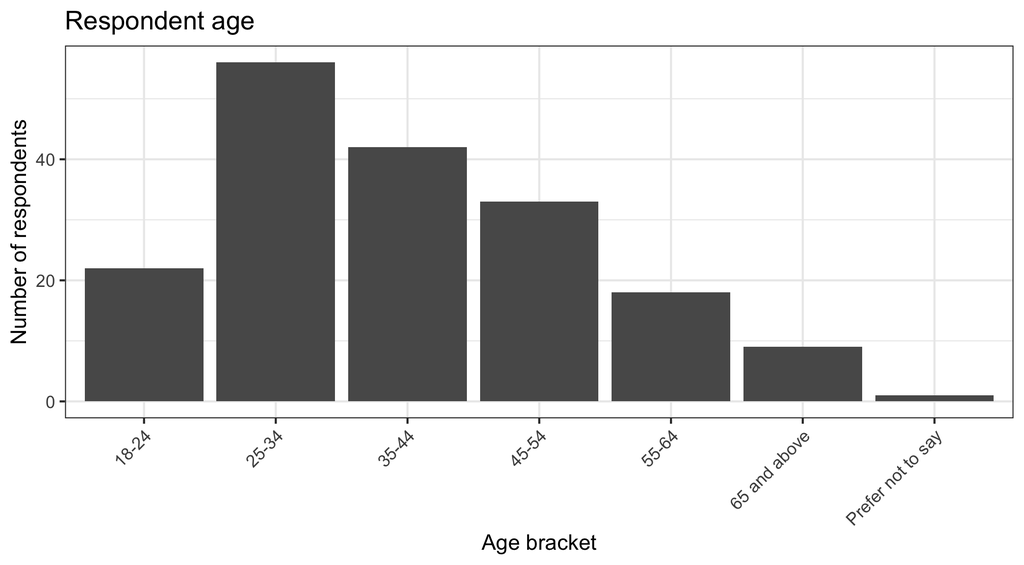

Figure 3: Respondent age

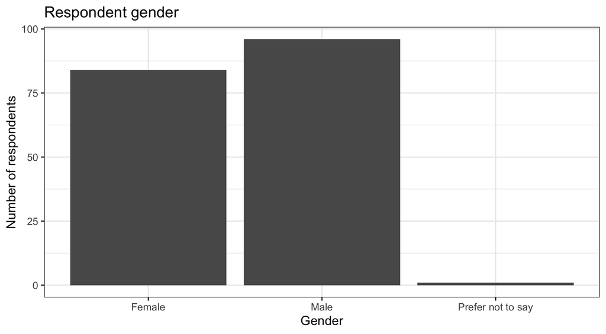

Figure 4: Respondent Gender

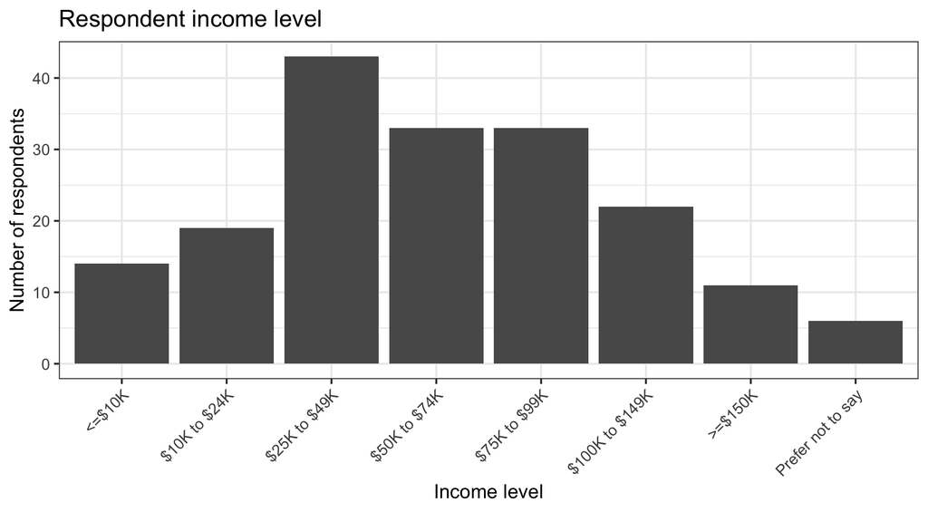

Figure 5: Respondent Income Level

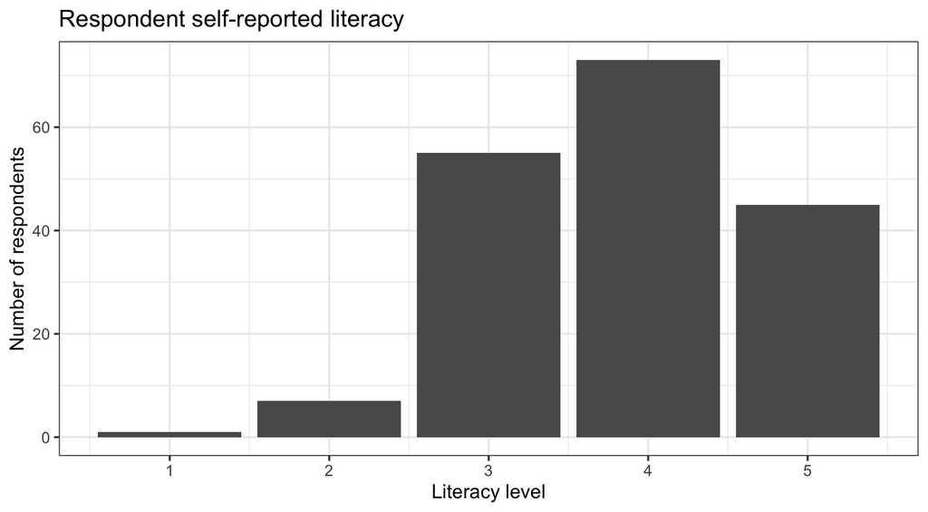

Figure 6: Respondent Digital Literacy

5. **Functionality**: Nearly all respondents (e.g., >90%) use their phone for texting, emails, online shopping, social media, and listening to music as shown in table 2 below.

| Function | n | Percent of total |
| --- | --- | --- |
| Text messaging | 176 | 97 |
| Online shopping | 176 | 97 |
| Email | 171 | 94 |
| Browsing social media | 168 | 93 |
| Listening to music | 166 | 92 |
| Voice calling | 150 | 83 |
| Ordering food delivery | 127 | 70 |
| Managing your calendar | 125 | 69 |
| Requesting rides | 112 | 62 |
| Productivity | 110 | 61 |

Table 2: Respondent mobile phone use cases

| Race | n | Percent of total |
| --- | --- | --- |
| White | 122 | 67 |
| African Amerian | 38 | 21 |
| Hispanic / Latino | 14 | 8 |
| Asian | 13 | 7 |
| Two or more | 12 | 7 |
| American Indian / Alaska Native | 4 | 2 |
| Native Hawaiian / Pacific Islander | 1 | 1 |

Table 3: Respondent race

# Modeling

In our baseline (i.e., simple) logit model, the utility $u_j$ for alternative $j$ is modeled as a linear combination of the attributes of the alternative. The mathematical representation of the utility function is:

$$u_j = \beta_1 x_j^{\mathrm{Price}} + \beta_2 x_j^{\mathrm{QuestionLimit}} + \beta_3 \delta_j^{\mathrm{FunctionalityMedium}} + \beta_3 \delta_j^{\mathrm{FunctionalityHigh}}+ \varepsilon_j$$

## Baseline Coefficient Interpretations

1. **Price**: The negative coefficient indicates that as the price of an alternative increases, its utility decreases, making it less likely to be chosen. For every one-unit increase in price, the utility decreases by 0.188 units. This reflects consumer sensitivity to cost, where higher prices reduce the attractiveness of an option.
2. **Question Limit**: The positive coefficient suggests that an increase in the question limit enhances the utility of the alternative. For every additional unit increase in question limit, utility increases by 0.002 units. This implies that consumers value having a higher question limit, associating it with greater functionality or value.
3. **Functionality Medium**: This positive coefficient indicates that alternatives with medium functionality provide an additional 1.517 units of utility compared to the baseline functionality (low functionality). Consumers perceive medium functionality as a meaningful improvement over low functionality.
4. **Functionality High**: This coefficient, larger than the coefficient for medium functionality, indicates that alternatives with high functionality provide an additional 2.534 units of utility compared to the baseline functionality (low functionality). High functionality is even more preferred than medium functionality, and the larger coefficient reflects the strength of this preference.

The summary figure below (Figure 7) of simple logit model coefficient indicates the relative importance of each attribute in determining utility. The negative estimate for price (-0.188) shows that higher prices decrease utility significantly, while its small standard error (0.009) suggests precise estimation. The positive coefficient for question limit (0.002) reflects that higher limits increase utility, with strong statistical significance. Medium functionality (1.517) and high functionality (2.534) coefficients demonstrate that functionality is a major driver of utility, with high functionality being more impactful, and their standard errors show confidence in these estimates.

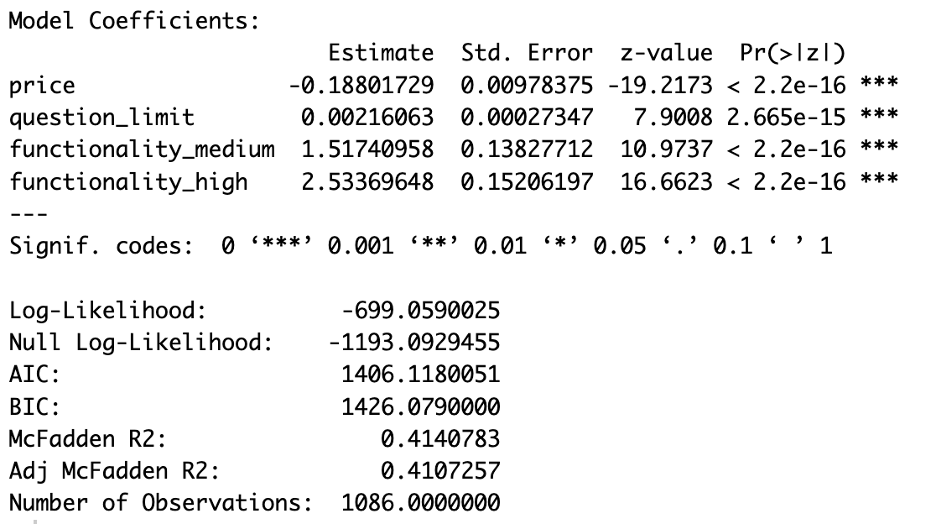

Figure 7: Summary table of simple utility coefficient estimates with standard errors

In addition to the baseline model, a mixed-logit and subgroup model was fit to the data. The mixed-logit model used log-normal distributions to model the price and question limit parameters as they are both continuous and non-negative values within the option space. The coefficient summary for all models is shown below in Table 4.

| Parameter | Simple Logit | Sub-group Logit | Mixed Logit |
| --- | --- | --- | --- |
| price | -0.188 | -0.180 | -15.768 |
| question_limit | 0.002 | 0.002 | -6.661 |
| functionality_medium | 1.517 | 1.608 | 1.121 |
| functionality_high | 2.534 | 2.687 | 1.790 |
| price_Older | - | -0.028 | - |
| question_limit_Older | - | -0.001 | - |
| functionality_medium_Older | - | -0.264 | - |
| functionality_high_Older | - | -0.473 | - |
| sd_price | - | - | -0.438 |
| sd_question_limit | - | - | 0.096 |

Table 4: Summary table of utility coefficient estimates

### Willingness to pay

Figure 8 demonstrates clear and significant preferences for the evaluated attributes. The “Question Limit” attribute shows a strong positive linear trend in WTP, indicating that consumers are willing to pay more as the question limit increases. The relatively narrow confidence intervals confirm the consistency and reliability of this preference. Similarly, the “Functionality” attribute displays a clear differentiation, with WTP increasing markedly from “Low” to “High.” The distinct confidence intervals across levels highlight the importance of functionality as a driver of consumer choice. Overall, the Simple Logit Model identifies both question limit and functionality as key attributes influencing consumer preferences, with relatively low uncertainty compared to other models.

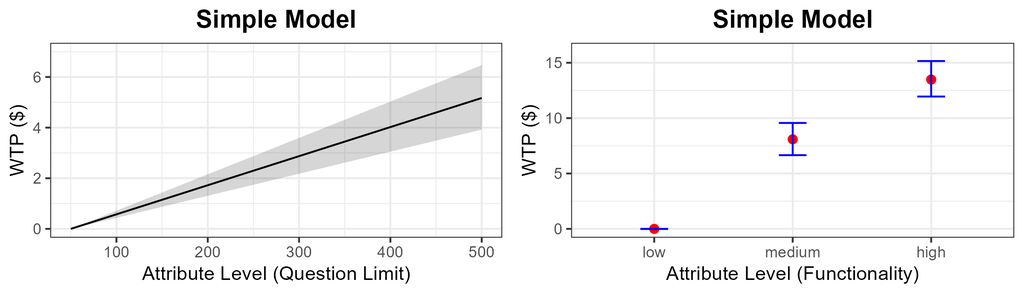

Figure 8: Simple Model of WTP for Question Limit and Functionality Attributes

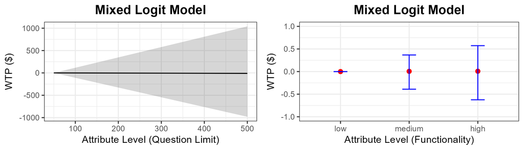

Figure 9: Mixed Logit Model of WTP for Question Limit and Functionality Attributes

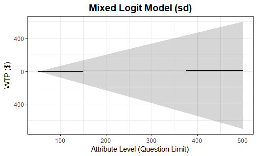

Figure 10: Mixed Logit Model S.D of WTP for Question Limit Attributes

Figure 11 highlights the importance of both attributes, though with slightly greater uncertainty compared to the Simple Logit Model. For the “Question Limit” attribute, WTP shows a consistent upward trend, suggesting that consumers are willing to pay more for increased limits. However, the wider confidence intervals indicate greater variability in preferences among different sub-groups. The “Functionality” attribute continues to demonstrate a positive relationship with WTP, as higher levels of functionality correspond to increased WTP. Confidence intervals for functionality levels remain distinct, emphasizing its strong influence on consumer choice. This model reinforces the relevance of both attributes while accounting for variations across sub-groups.

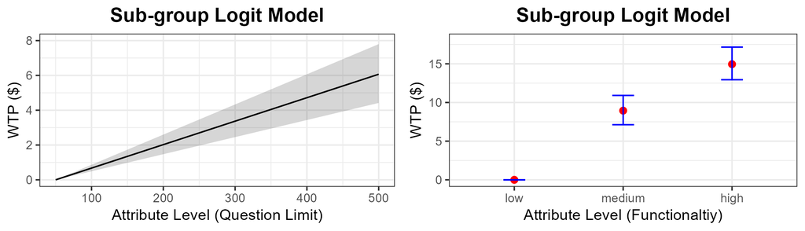

Figure 11: Sub-group Logit Model of WTP for Question Limit and Functionality Attributes

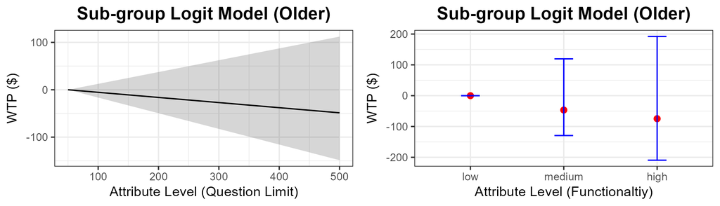

Figure 12: Sub-group Logit Model (Older Population) of WTP for Question Limit and Functionality Attributes

The WTP graphs use different types of visualizations because they are tailored to the nature of the data and the insights each model aims to highlight. Line plots are used for continuous attributes like “Question Limit” to show trends across a range, while bar or point plots are better suited for categorical attributes like “Functionality,” allowing for easy comparison across discrete levels. Standard deviation graphs are included in mixed logit models to emphasize variability in preferences among consumers, highlighting heterogeneity. Sub-group graphs, such as those for older populations, are used to focus on specific demographic differences. Each type of graph is chosen to clearly and effectively communicate the results based on the type of attribute, the model being analyzed, and the target audience’s need for understanding.

# Market Simulation and Scenarios

The simulated market scenario evaluates the competitive positioning of four AI-enabled products: Apple Siri, ChatGPT, Google Gemini, and Our Product. These products are assessed based on three critical attributes: Price, Functionality, and Question Limit, reflecting key consumer decision-making factors for AI services. The input values for the simulation were carefully chosen based on official documentation, publicly available data, and reasonable assumptions where direct information was unavailable.

- **Price**: Apple Siri: $0; ChatGPT: $19.99; Google Gemini: $19.99; Our Product: $15. These prices were validated against official sources to ensure accuracy ([1], [2], [3]).
- **Functionality**: Apple Siri was assigned “low functionality” (functionality_medium = 0, functionality_high = 0), ChatGPT was assigned “medium functionality” (functionality_medium = 1, functionality_high = 0), and Google Gemini was assigned “high functionality” (functionality_medium = 0, functionality_high = 1). These assignments are based on the documented capabilities of each product ([1], [2], [3]).
- **Question Limit**s: Apple Siri was assigned a conservative 50 questions/day to reflect its free nature. ChatGPT and Our Product were assigned 250 questions/day, aligning with ChatGPT’s Plus plan. Google Gemini was assigned a higher limit of 500, reflecting its enterprise-oriented design and enhanced capabilities ([2], [3]).

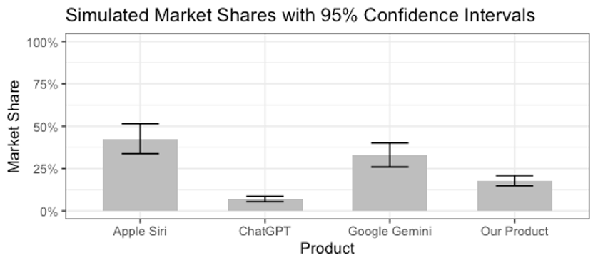

Figure 13: Simulated Market Shares with 95% Confidence Intervals

Insights from Figure 13:

Opportunities for Increasing Demand Key drivers for enhancing adoption include:

1. Price Sensitivity: Apple Siri and Google Gemini demonstrate the importance of competitive pricing. Reducing Our Product’s price to $10 could significantly boost its market share.
2. Functionality Upgrades: Enhancing functionality from “Medium” to “High” would position Our Product more competitively against Google Gemini.
3. Question Limit Expansion: Increasing the question limit to 500 could appeal to niche segments seeking higher usage flexibility, though its impact is less significant compared to price and functionality.

## Sensitivity Analysis

### Market Share vs. Price

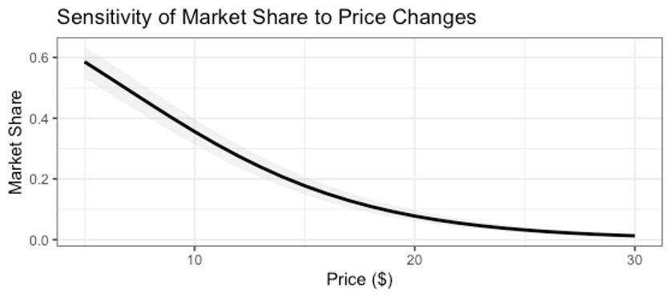

Figure 14: Sensitivity of Market Share to Price Changes

### Tornado Plot Analysis

Figure 15 provides a detailed view of how variations in price, functionality, and question limits influence market share:

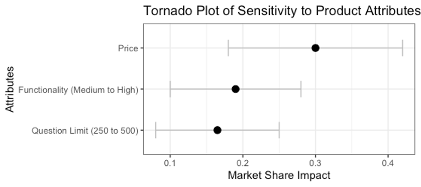

Figure 15: Tornado Plot of Sensitivity to Product Attributes

### Recommendations

# Final Recommendations and Conclusions

## Key Insights

- **Price Sensitivity**: Price remains the dominant factor influencing consumer choice. A price point higher than $15 results in substantial losses in market share, as shown in the sensitivity analysis.
- **Functionality**: High functionality is crucial for competing with premium offerings like Google Gemini, which successfully balances price and features.
- **Question Limit**: While a secondary driver, increasing the question limit could enhance perceived value among heavy users.

## Recommendations

- **Pricing Strategy**: Adjust the price of our product to $10 to maximize market share while remaining competitive.
- **Functionality Upgrade**: Invest in upgrading functionality to High, allowing direct competition with Google Gemini in the premium segment.
- **Question Limit Enhancement**: Increase the question limit to 500, differentiating the product and appealing to specific segments.

## Opportunities for Growth

- **Target Premium Users**: By offering high functionality at a competitive price, our product can attract users willing to pay for advanced features.
- **Bundling**: Integrating additional services or partnerships can increase perceived value.
- **Marketing**: Highlight affordability and advanced functionality in promotional campaigns.

## Limitations and Uncertainties

- **Sample Representation**: Insights are derived from a specific respondent pool, which may not fully represent diverse consumer segments. Expanding the survey could improve generalizability.
- **Market Dynamics**: The analysis assumes static competitor offerings, which may change due to innovation or new product launches.
- **Attribute Scope**: Attributes like integration, privacy, integration capabilities and reliability (brand trust) were not considered but could influence adoption.
- **Stated vs. Actual Preferences**: Findings are based on survey data and may not fully capture real-world purchasing behavior. Future studies involving real-world trials could provide additional validation.

# Appendix

## Final survey

The snapshot below shows the final survey that was fielded and completed by respondents. The choice conjoint questions that do not populate follow the form described and shown above.

# Mobile AI Functionality: Final Survey

Author

Taekwon Choi, Stephen Hilton, Bryce Huffman, Vidyullatha KS, Faizan Mufti

Published

November 17, 2024

## Welcome

Welcome and thank you for taking our survey. We are a student group from The George Washington University, and we are interested in what would make having an **AI software service on your smartphone** desirable to you.

[figure not shown]

## Consent

This survey is being conducted by students at The George Washington University. We will not be collecting any identifying data, such as your name or address. The entire survey will take approximately 10 to 15 minutes to complete. Your participation is voluntary, and you may stop the survey at any time.

By taking this survey, I acknowledge that I am at least 18 years of age. I also acknowledge that my participation in this survey is voluntary and that I may withdraw at any time.

I have read and understand the above information.

Yes

No

## Education information

**1. Price**: The amount you are willing to *pay per month* for the AI software service.

**2. Functionality**: The AI software can assist with or complete various tasks such as posting on social media, reading text messages, ordering food, making reservations, transcribing calls, and more.

The functionality of the AI is categorized into three levels: Low, Medium, and High.

- *Low* functionality: Complete a task within *one* source (e.g., edit grammar of an email draft)
- *Medium* functionality: Complete a task with up to *three* sources (e.g., check calendar to schedule a video call via email)
- *High* functionality: Complete a task with access to *all* relevant sources (i.e., cross-reference calendar, email, messages, and a flight booking website to help book the best flight)

**Note**

If a task requires multiple sources, the AI tool will be able to seamlessly work between each.

**3. Question limit**: The number of questions or requests that you can ask the AI software *per day* (e.g., each input, such as “can you revise this email?” counts as a question)

## Choice Practice

We’ll now begin the choice questions. For each question below, please choose the option you would most prefer.

If these were your only options, which AI-enabled smartphone software service would you choose?

$5 per month

$25 per month

$50 per month

If these were your only options, which AI-enabled smartphone software service would you choose?

Ability to complete a task within one source

Ability to complete a task with up to three sources

Ability to complete a task with all relevant sources

If these were your only options, which AI-enabled smartphone software service would you choose?

Can ask up to 50 questions per day

Can ask up to 250 questions per day

Can ask up to 500 questions per day

# Choice Question Intro

Great work!

We will now show you 6 sets of choice questions. Please select the option you would most prefer.

Click the **next** button to begin.

# Question 1

# Question 2

# Question 3

# Question 4

# Question 5

# Question 6

## Demographic information

Awesome, thank you for completing the choice questions!

Now, please fill out the demographic questions below.

What is your age range? [select one]

18-24

25-34

35-44

45-54

55-64

65 and above

Prefer not to say

What is your current gender identity? [select one]

Male

Female

Non-binary

Other

Prefer not to say

Please specify your current gender identity:

What is your income level? [select one]

Less than $10,000

$10,000 to $24,999

$25,000 to $49,999

$50,000 to $74,999

$75,000 to $99,999

$100,000 to $149,999

$150,000 or more

Prefer not to say

I identify my race as (select all that apply):

White

African American

Asian

Hispanic/Latino

American Indian/Alaska Native

Native Hawaiian/Pacific Islander

Prefer not to say

In which industry do you work? [select one]

Agriculture

Data Processing

Defense

Education

Entertainment

Finance

Food Services

Health Care

Hotel Services

IT

Legal

Marketing

Professional Services

Utilities

Other

Prefer not to say

Please specify your current industry:

## Other questions

Almost there! Please complete the last few questions below to finish the survey.

On a scale from 1-5, how digitally literate would you describe yourself? [select one]

1 [Few digital skills]

2

3

4

5 [Advanced digital user]

Who makes your current smartphone? [select one]

Apple

Google

Samsung

Huawei

Other

Unsure

Please specify who makes your current smartphone:

Which of the following functions of your smartphone do you use? [select all that apply]

Voice calling

Email

Text messaging

Managing your calendar

Browsing social media (e.g., Instagram, Facebook, X)

Listening to music (e.g., Spotify, Amazon, Apple)

Online shopping (e.g., Amazon, Target)

Ordering food delivery (e.g. Uber Eats, Toast, Grubhub, DoorDash)

Requesting rides (e.g., Uber, Lyft)

Productivity (e.g., Google Drive, Box, Microsoft Office)

# End Page

You’ve completed the survey. Thank you for your participation!

You may close the window now.